# Assignment 3: Model comparison

### Model diagnostics

#### Build the more complex model

In order to test the more complex model for outliers and to test the assumptions first build the model.

```r
# Model 1: Demographic predictors
model_1 <- lm(pain ~ age + sex, data = df)

# Model 2: Full model with psychological and hormonal predictors
model_2 <- lm(pain ~ age + sex + STAI_trait + pain_cat + mindfulness +
                cortisol_serum + cortisol_saliva, data = df)

# -------------------------------
# Summarize both models
# -------------------------------

summary(model_1)
```

```
##
## Call:
## lm(formula = pain ~ age + sex, data = df)
##
## Residuals:
##     Min      1Q  Median      3Q     Max
## -3.6617 -0.9974  0.1464  1.0508  3.5026
##
## Coefficients:
##             Estimate Std. Error t value Pr(>|t|)
## (Intercept)  8.49145    0.94828   8.955 9.64e-16 ***
## age         -0.08906    0.02304  -3.865 0.000163 ***
## sexmale      0.10287    0.23268   0.442 0.659028
## ---
## Signif. codes:  0 '***' 0.001 '**' 0.01 '*' 0.05 '.' 0.1 ' ' 1
##
## Residual standard error: 1.464 on 156 degrees of freedom
## Multiple R-squared:  0.08784,    Adjusted R-squared:  0.07614
## F-statistic: 7.511 on 2 and 156 DF,  p-value: 0.0007684
```

```r
summary(model_2)
```

```
##
## Call:
## lm(formula = pain ~ age + sex + STAI_trait + pain_cat + mindfulness +
##     cortisol_serum + cortisol_saliva, data = df)
##
## Residuals:
##     Min      1Q  Median      3Q     Max
## -3.2327 -0.7776 -0.0420  0.7737  2.9571
##
## Coefficients:
##                 Estimate Std. Error t value Pr(>|t|)
## (Intercept)      1.33791    1.72512   0.776  0.43923
## age             -0.02398    0.02415  -0.993  0.32223
## sexmale          0.31654    0.21062   1.503  0.13496
## STAI_trait      -0.02539    0.02787  -0.911  0.36382
## pain_cat         0.09509    0.02877   3.305  0.00119 **
## mindfulness     -0.12801    0.12509  -1.023  0.30779
## cortisol_serum   0.16651    0.24532   0.679  0.49833
## cortisol_saliva  0.43770    0.25213   1.736  0.08460 .
## ---
## Signif. codes:  0 '***' 0.001 '**' 0.01 '*' 0.05 '.' 0.1 ' ' 1
##
## Residual standard error: 1.242 on 151 degrees of freedom
## Multiple R-squared:  0.3647, Adjusted R-squared:  0.3352
## F-statistic: 12.38 on 7 and 151 DF,  p-value: 1.793e-12
```

#### Checking for influential outliers

```r
# -------------------------------
# MODEL DIAGNOSTICS FUNCTION
# -------------------------------
check_model_diagnostics <- function(model, data, vif_threshold = 5) {
  cat("=== OUTLIER CHECKS ===\n")

  # --- Standardized residuals ---
  std_res <- rstandard(model)
  outliers_std <- which(abs(std_res) > 3)
  if (length(outliers_std) > 0) {
    cat("Standardized residuals > |3| at:\n")
    print(outliers_std)
  } else {
    cat("No large standardized residuals detected.\n")
  }

  # --- Leverage values ---
  n <- nrow(data)
  p <- length(coef(model)) - 1
  leverage_vals <- hatvalues(model)
  leverage_cutoff <- 2 * (p + 1) / n
  outliers_lev <- which(leverage_vals > leverage_cutoff)
  cat("\nHigh leverage (>", round(leverage_cutoff, 3), ") at:\n")
  print(outliers_lev)

  # --- Cook's distance ---
  cooks_d <- cooks.distance(model)
  cooks_cutoff <- 4 / n
  outliers_cook <- which(cooks_d > cooks_cutoff)
  cat("\nHigh Cook's Distance (>", round(cooks_cutoff, 3), ") at:\n")
  print(outliers_cook)

  # --- Optional: return a summary of all flagged rows ---
  unique_outliers <- sort(unique(c(outliers_std, outliers_lev, outliers_cook)))
  if (length(unique_outliers) > 0) {
    cat("\nFlagged observations (rows):\n")
    print(unique_outliers)
    cat("\nView flagged rows:\n")
    print(data[unique_outliers, ])
  } else {
    cat("\nNo major outliers detected based on the combined criteria.\n")
  }

  # ==========================
  cat("\n=== ASSUMPTION CHECKS ===\n")

  # --- Normality of residuals ---
  cat("\nChecking normality of residuals (Q-Q Plot)...\n")
  plot(model, which = 2)

  # --- Linearity + Homoscedasticity ---
  cat("Checking linearity & homoscedasticity (Residuals vs Fitted)...\n")
  plot(model, which = 1)

  # --- Scale-Location plot for homoscedasticity ---
  cat("Checking variance of residuals (Scale-Location)...\n")
  plot(model, which = 3)

  # --- Multicollinearity ---
  if (!requireNamespace("car", quietly = TRUE)) {
    install.packages("car")
  }
  library(car)
  vif_values <- vif(model)

  cat("\nVIF values:\n")
  print(vif_values)

  high_vif <- vif_values[vif_values > vif_threshold]
  if (length(high_vif) > 0) {
    cat("\n⚠️  WARNING: VIF values above threshold (", vif_threshold, "):\n")
    print(high_vif)
  } else {
    cat("\n✅ VIF values are acceptable (below threshold of ", vif_threshold, ").\n")
  }

  invisible(list(
    outliers = unique_outliers,
    vif = vif_values
  ))
}
```

#### Checking assumptions

Check the normality assumption.

```r
#above
```

[output not shown]

Check the linearity assumption.

```r
#above
```

[output not shown]

Check the homoscedasticty assumption (homogeneity of variance).

```r
#above
```

[output not shown]

Check the multicollinearity assumption.

(VIF above 5), or a VIF threshold of 3 is recommended in this paper: http://onlinelibrary.wiley.com/doi/10.1111/j.2041-210X.2009.00001.x/full

Some info about VIF: https://statisticalhorizons.com/multicollinearity http://blog.minitab.com/blog/understanding-statistics/handling-multicollinearity-in-regression-analysis

```r
#above
```

[output not shown]

### Making decision based on model diagnostics

If based on the assumption tests you decide to drop a predictor variable you should do that here. Create your updated model.

```r
# -------------------------------
# Auto-drop high VIF predictors and refit model
# -------------------------------
auto_drop_high_vif <- function(model, data, vif_threshold = 3) {
  if (!requireNamespace("car", quietly = TRUE)) install.packages("car")
  library(car)

  # Extract the formula and terms
  original_formula <- formula(model)
  terms <- attr(terms(model), "term.labels")
  response <- all.vars(formula(model))[1]

  # Calculate initial VIFs
  vif_vals <- vif(model)

  # Keep dropping vars with highest VIF until all are below threshold
  while (any(vif_vals > vif_threshold)) {
    worst_vif_var <- names(which.max(vif_vals))
    cat("⚠️  Removing predictor due to high VIF (>", vif_threshold, "):", worst_vif_var, "\n")

    # Remove this variable from the list of predictors
    terms <- setdiff(terms, worst_vif_var)

    # Refit model without it
    new_formula <- as.formula(paste(response, "~", paste(terms, collapse = " + ")))
    model <- lm(new_formula, data = data)

    # Recalculate VIF
    vif_vals <- vif(model)
  }

  cat("✅ Final model has all VIFs below", vif_threshold, "\n")
  print(vif_vals)

  return(model)
}

# Fit the full model again
model_2 <- lm(pain ~ age + sex + STAI_trait + pain_cat + mindfulness +
                cortisol_serum + cortisol_saliva, data = df)

# Automatically drop predictors with VIF > 3
model_updated <- auto_drop_high_vif(model_2, df, vif_threshold = 3)
```

```
## ⚠️  Removing predictor due to high VIF (> 3 ): cortisol_saliva
## ✅ Final model has all VIFs below 3
##            age            sex     STAI_trait       pain_cat    mindfulness
##       1.403102       1.140201       1.932533       1.863522       1.516941
## cortisol_serum
##       1.524561
```

#### Checking outliers of the updated model

```r
# \outlier and assumption diagnostics on the updated model
diagnostics_updated <- check_model_diagnostics(model_updated, df)
```

```
## === OUTLIER CHECKS ===
## No large standardized residuals detected.
##
## High leverage (> 0.088 ) at:
##  14  32  49  81  86 110 134 135
##  14  32  49  81  86 110 134 135
##
## High Cook's Distance (> 0.025 ) at:
##  15  81 105 106 110 134 138 144 149
##  15  81 105 106 110 134 138 144 149
##
## Flagged observations (rows):
##  [1]  14  15  32  49  81  86 105 106 110 134 135 138 144 149
##
## View flagged rows:
## # A tibble: 14 × 12
##    ID      pain sex      age STAI_trait pain_cat cortisol_serum cortisol_saliva
##    <chr>  <dbl> <fct>  <dbl>      <dbl>    <dbl>          <dbl>           <dbl>
##  1 ID_14      5 female    45         37       40           4.72            3.88
##  2 ID_15      7 female    32         34       25           5.89            5.94
##  3 ID_32      1 female    43         27       14           3.09            2.96
##  4 ID_49      2 male      49         26       15           3.86            3.85
##  5 ID_81      8 male      46         37       24           6.78            6.37
##  6 ID_86      3 male      51         37       26           2.7             2.53
##  7 ID_105     7 female    38         38       21           5.46            4.9
##  8 ID_106     1 female    43         50       26           3.99            3.99
##  9 ID_110     4 male      37         41       31           6.9             6.29
## 10 ID_134     7 male      39         36       39           3.65            3.92
## 11 ID_135     7 male      24         40       38           5.05            5.85
## 12 ID_138     6 female    47         41       24           4.14            5.06
## 13 ID_145     7 male      40         39       30           3.46            3.86
## 14 ID_150     2 male      48         48       30           5.25            5.82
## # ℹ 4 more variables: mindfulness <dbl>, weight <dbl>, IQ <dbl>,
## #   household_income <dbl>
##
## === ASSUMPTION CHECKS ===
##
## Checking normality of residuals (Q-Q Plot)...
```

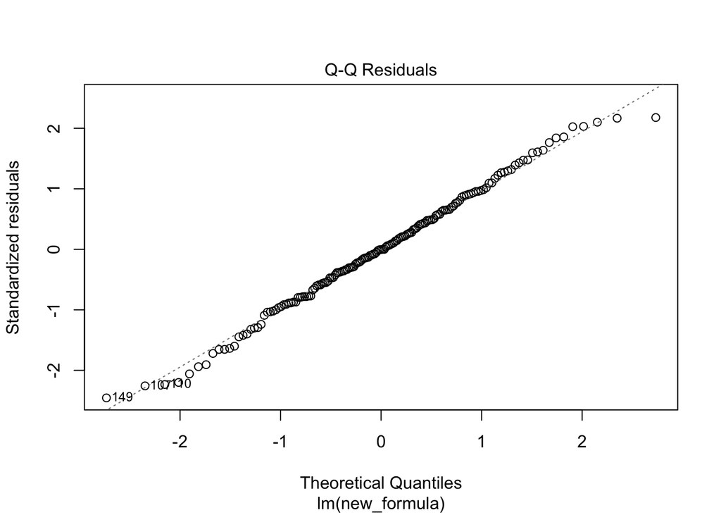

```
## Checking linearity & homoscedasticity (Residuals vs Fitted)...
```

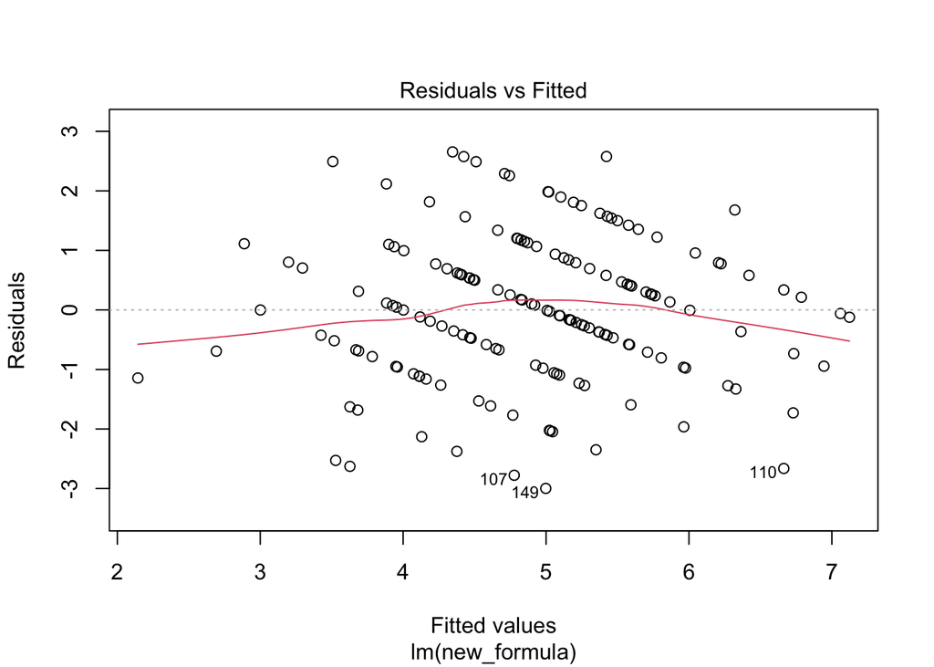

```
## Checking variance of residuals (Scale-Location)...
```

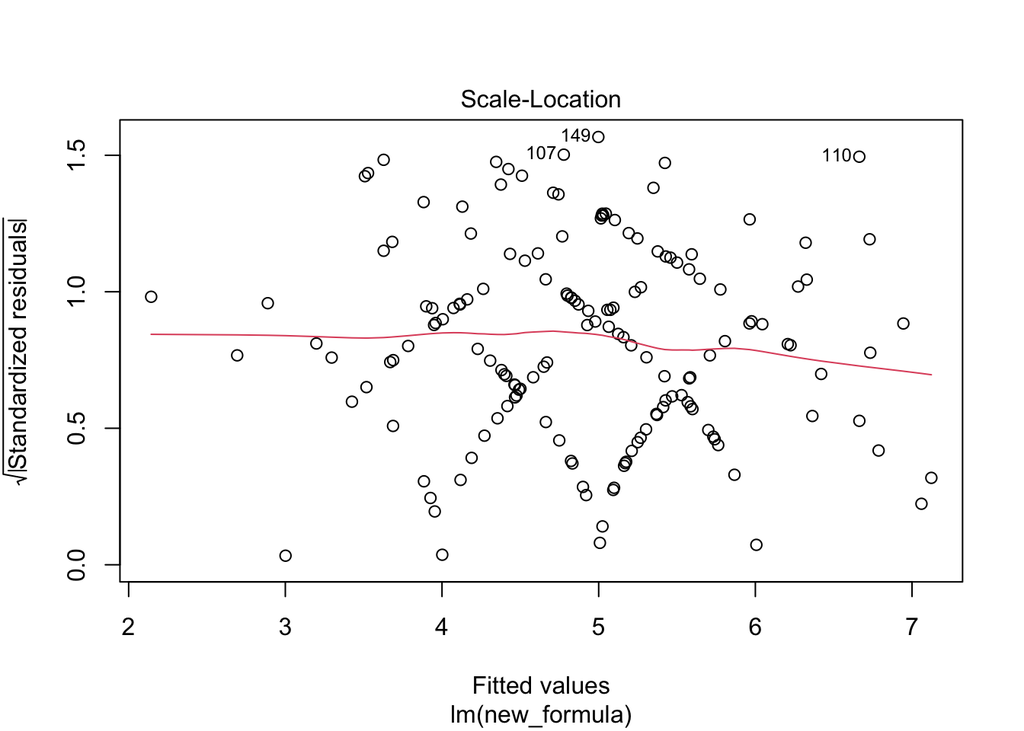

```
##
## VIF values:
##            age            sex     STAI_trait       pain_cat    mindfulness
##       1.403102       1.140201       1.932533       1.863522       1.516941
## cortisol_serum
##       1.524561
##
## ✅ VIF values are acceptable (below threshold of  5 ).
```

#### Checking assumptions of the updated model

Normality assumption

```r
#above
```

Linearity assumption

```r
#above
```

Homoscedasticty assumption (homogeneity of variance)

Multicollinearity assumption

```r
#above
```